# Municipal Service Request Analytics – Bengaluru

Rishav Prakash

2026-08-04

# 1. Introduction

Municipal services play an important role in maintaining the quality of urban life. Citizens regularly report civic issues such as garbage collection, drainage problems, water supply issues, road maintenance, and sanitation.

This project focuses on analysing municipal citizen grievances in Bengaluru using data associated with Bruhat Bengaluru Mahanagara Palike (BBMP).

The study uses descriptive analytics to understand complaint patterns, geographical distribution, reporting frequency, and grievance status.

# 2. Research Question

What are the patterns and trends in municipal citizen grievances in Bengaluru based on complaint category, geographical distribution, reporting frequency, and grievance status?

# 3. Research Objectives

1. To identify the most frequently reported types of municipal grievances.
2. To analyse the distribution of grievances across different wards.
3. To examine monthly trends in grievance reporting.
4. To study the distribution of grievances based on their recorded status.

# 4. Type of Analytics

This project uses descriptive analytics to summarize historical grievance records using frequencies, percentages, basic statistical summaries, and graphical representations.

# 5. Tools and Technologies

- R Programming
- RStudio
- R Markdown
- ggplot2
- dplyr
- readr
- lubridate
- janitor

# 6. Dataset Description

The study uses the BBMP Citizen Grievances dataset, containing 1,230,890 records and 12 variables.

The dataset provides information about citizen complaints submitted to the municipal authority in Bengaluru. The variables include complaint category, subcategory, grievance date, zone, ward, grievance mode, grievance status, staff information, and citizen rating.

The dataset provides an opportunity to examine the frequency and distribution of municipal grievances across different categories and geographical areas, along with their reporting patterns and recorded status.

# 7. Data Import and Inspection

```r
library(readr)
library(dplyr)
library(ggplot2)
library(janitor)
library(lubridate)
library(knitr)

# Import original dataset
raw_data <- read_csv(
  "data/citizen-grievances.csv.gz",
  col_types = cols(
    `Grievance Date` = col_character()
  ),
  show_col_types = FALSE
)

# Clean column names
raw_data <- clean_names(raw_data)

# Display dataset dimensions
dim(raw_data)
```

```
## [1] 1230890      12
```

```r
# Display column names
names(raw_data)
```

```
##  [1] "complaint_id"      "category"          "sub_category"
##  [4] "grievance_date"    "zone_name"         "ward_name"
##  [7] "grievance_mode"    "grievance_status"  "staff_remarks"
## [10] "staff_name"        "staff_designation" "rating"
```

```r
# Display first six records
head(raw_data)
```

```
## # A tibble: 6 × 12
##   complaint_id category          sub_category grievance_date zone_name ward_name
##          <dbl> <chr>             <chr>        <chr>          <chr>     <chr>
## 1     21236361 Electrical        Street Ligh… 2026-08-21 10… RRNagar   Jnanabha…
## 2     21236360 Electrical        Street Ligh… 2026-08-21 10… South     J.P.Nagar
## 3     21236359 Road Maintenance… footpath en… 2026-08-21 10… West      K.R.Mark…
## 4     21236358 Electrical        Street Ligh… 2026-08-21 10… C.V. Ram… Indirana…
## 5     21236357 Solid Waste (Gar… Garbage veh… 2026-08-21 10… Jayanagar Beguru
## 6     21236356 Road Infrastruct… Road Infras… 2026-08-21 10… East      Kacharak…
## # ℹ 6 more variables: grievance_mode <chr>, grievance_status <chr>,
## #   staff_remarks <chr>, staff_name <chr>, staff_designation <chr>,
## #   rating <dbl>
```

## 7.1 Data Quality Assessment

```r
# Check missing values
colSums(is.na(raw_data))
```

```
##      complaint_id          category      sub_category    grievance_date
##                 0                 0                 0                 0
##         zone_name         ward_name    grievance_mode  grievance_status
##               587                 0               587                57
##     staff_remarks        staff_name staff_designation            rating
##             23006                57               587           1190790
```

```r
# Check duplicate records
sum(duplicated(raw_data))
```

```
## [1] 0
```

```r
# Check unique complaint IDs
n_distinct(raw_data$complaint_id)
```

```
## [1] 1230890
```

```r
# Complaint category distribution
sort(table(raw_data$category), decreasing = TRUE)
```

```
##
##                    Electrical Solid Waste (Garbage) Related
##                        429277                        361295
##        Road Maintenance(Engg)                        Forest
##                        175522                         57769
##                    veterinary                   Health Dept
##                         51953                         42281
##      E khata / Khata services           Road Infrastructure
##                         24992                         20174
##                        Others       Storm  Water Drain(SWD)
##                         13634                          8589
##            Revenue Department                 Town Planning
##                          8435                          6613
##        Parks and Play grounds                 Advertisement
##                          6105                          5409
##                       Markets                    Sanitation
##                          3980                          3568
##                         Lakes                CORONA COVID19
##                          3192                          2044
##                  Water Crisis   Traffic Engineer Cell (TEC)
##                          1147                          1006
##                Indira Canteen    Optical Fiber Cables (OFC)
##                           828                           607
##                       Plastic        Information Technology
##                           378                           356
##         Property Tax services                        Estate
##                           344                           334
##              Projects Central                   Call Center
##                           331                           235
##               Welfare Schemes          BBMP Election Branch
##                           225                           137
##                     Education                   Major Roads
##                           128                             2
```

```r
# Grievance status distribution
table(raw_data$grievance_status)
```

```
##
##             Closed        In Progress Long Term Solution       Non Relevant
##            1118036               1076                522              26929
##         Registered           Rejected             ReOpen           Resolved
##              56494              16803               4020               6953
```

The initial inspection identified 1,230,890 grievance records across 12 variables.

No exact duplicate rows or missing complaint IDs were identified. However, missing values were observed in several columns, particularly the Rating variable.

The Rating variable contains a substantial proportion of missing observations and will not be used as a major variable in this analysis.

## 7.2 Date Inspection and Cleaning

```r
# Convert grievance date
raw_data$grievance_date <- as.POSIXct(
  raw_data$grievance_date,
  format = "%Y-%m-%d %H:%M:%S",
  tz = "UTC"
)

# Check date range
range(raw_data$grievance_date, na.rm = TRUE)
```

```
## [1] "1900-01-01 12:00:00 UTC" "2048-02-28 10:13:00 UTC"
```

```r
# Create cleaned dataset
clean_data <- raw_data %>%
  filter(
    grievance_date >= as.POSIXct("2020-01-01", tz = "UTC"),
    grievance_date < as.POSIXct("2027-01-01", tz = "UTC")
  )

# Check cleaned dataset dimensions
dim(clean_data)
```

```
## [1] 1230416      12
```

The original dataset contains some unusual dates, including records from 1900 and 2048.

These records are excluded from the initial analysis because they fall outside the selected study period. Their original values are retained in the imported dataset.

# 8. Geographical Distribution of Grievances

The dataset contains 485 unique ward names across Bengaluru.

Rajarajeshwari Nagar, Begur, and Bellandur also appear among the wards with relatively high grievance counts.

## 8.1 Ward-wise Summary

```r
# Count unique wards
n_distinct(clean_data$ward_name)
```

```
## [1] 485
```

```r
# Calculate ward-wise complaints
ward_summary <- clean_data %>%
  count(ward_name, sort = TRUE)

# Display top 10 wards
head(ward_summary, 10)
```

```
## # A tibble: 10 × 2
##    ward_name                n
##    <chr>                <int>
##  1 Jnanabharathi Ward   27975
##  2 Horamavu             27206
##  3 Rajarajeshwari Nagar 24768
##  4 Begur                24674
##  5 Bellandur            21977
##  6 Hemmigepura          21500
##  7 Thanisandra          21257
##  8 Jakkur               20743
##  9 Hoodi                18397
## 10 Uttarahalli          17832
```

# 9. Data Visualization

## 9.1 Complaint Category Distribution

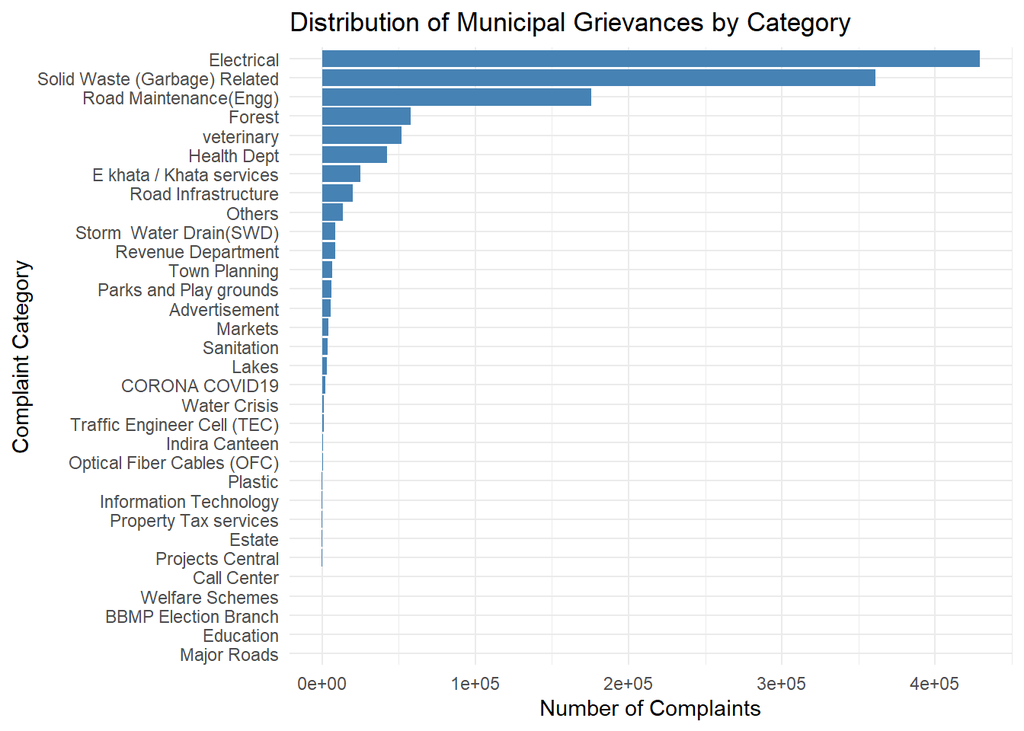

```r
# Calculate complaints by category
category_summary <- clean_data %>%
  count(category, sort = TRUE)

# Create bar graph
graph1 <- ggplot(
  category_summary,
  aes(x = reorder(category, n), y = n)
) +
  geom_col(fill = "steelblue") +
  coord_flip() +
  labs(
    title = "Distribution of Municipal Grievances by Category",
    x = "Complaint Category",
    y = "Number of Complaints"
  ) +
  theme_minimal()

# Display graph
graph1
```

```r
ggsave(
  "outputs/graphs/complaint_category.png",
  plot = graph1,
  width = 10,
  height = 7,
  dpi = 300
)
```

# 9.2 Monthly Grievance Trends

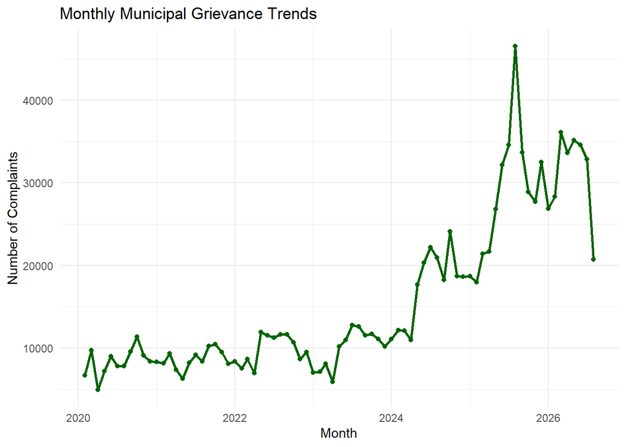

```r
# Calculate monthly complaints
monthly_summary <- clean_data %>%
  mutate(month = floor_date(grievance_date, "month")) %>%
  count(month)

# Create line graph
graph2 <- ggplot(
  monthly_summary,
  aes(x = month, y = n)
) +
  geom_line(color = "darkgreen", linewidth = 1) +
  geom_point(color = "darkgreen") +
  labs(
    title = "Monthly Municipal Grievance Trends",
    x = "Month",
    y = "Number of Complaints"
  ) +
  theme_minimal()

# Display graph
graph2
```

```r
ggsave(
  "outputs/graphs/monthly_trends.png",
  plot = graph2,
  width = 10,
  height = 6,
  dpi = 300
)
```

# 9.3 Ward-wise Complaint Distribution

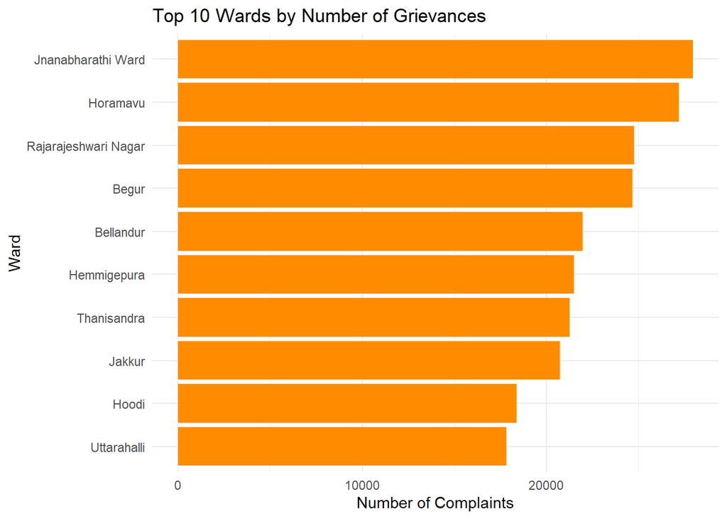

```r
# Select the top 10 wards
top_wards <- clean_data %>%
  count(ward_name, sort = TRUE) %>%
  slice_head(n = 10)

# Create graph
graph3 <- ggplot(
  top_wards,
  aes(x = reorder(ward_name, n), y = n)
) +
  geom_col(fill = "darkorange") +
  coord_flip() +
  labs(
    title = "Top 10 Wards by Number of Grievances",
    x = "Ward",
    y = "Number of Complaints"
  ) +
  theme_minimal()

graph3
```

```r
ggsave(
  "outputs/graphs/ward_distribution.png",
  plot = graph3,
  width = 10,
  height = 7,
  dpi = 300
)
```

# 9.4 Grievance Status Distribution

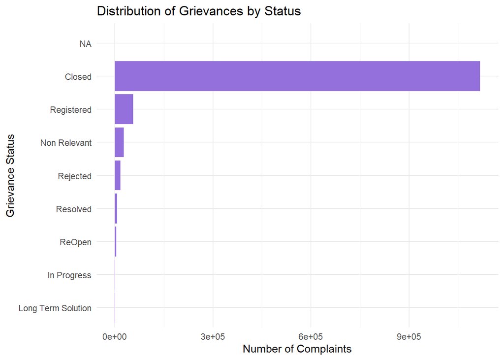

```r
# Calculate status distribution
status_summary <- clean_data %>%
  count(grievance_status, sort = TRUE)

# Create bar graph
graph4 <- ggplot(
  status_summary,
  aes(x = reorder(grievance_status, n), y = n)
) +
  geom_col(fill = "mediumpurple") +
  coord_flip() +
  labs(
    title = "Distribution of Grievances by Status",
    x = "Grievance Status",
    y = "Number of Complaints"
  ) +
  theme_minimal()

graph4
```

```r
ggsave(
  "outputs/graphs/status_distribution.png",
  plot = graph4,
  width = 10,
  height = 6,
  dpi = 300
)
```

Graphs will be generated using the cleaned dataset to examine the distribution of municipal grievances across different categories.

# 10. Descriptive Statistical Summary

```r
# Total number of grievances
total_complaints <- nrow(clean_data)

# Category summary
category_summary <- clean_data %>%
  count(category, sort = TRUE) %>%
  mutate(Percentage = round(n / total_complaints * 100, 2))

# Status summary
status_summary <- clean_data %>%
  count(grievance_status, sort = TRUE) %>%
  mutate(Percentage = round(n / total_complaints * 100, 2))

# Display category table
knitr::kable(
  head(category_summary, 10),
  caption = "Top 10 Grievance Categories"
)
```

Top 10 Grievance Categories

| category | n | Percentage |
| --- | --- | --- |
| Electrical | 429118 | 34.88 |
| Solid Waste (Garbage) Related | 361150 | 29.35 |
| Road Maintenance(Engg) | 175477 | 14.26 |
| Forest | 57756 | 4.69 |
| veterinary | 51899 | 4.22 |
| Health Dept | 42275 | 3.44 |
| E khata / Khata services | 24974 | 2.03 |
| Road Infrastructure | 20170 | 1.64 |
| Others | 13629 | 1.11 |
| Storm Water Drain(SWD) | 8587 | 0.70 |

```r
# Display status table
knitr::kable(
  status_summary,
  caption = "Grievance Status Summary"
)
```

Grievance Status Summary

| grievance_status | n | Percentage |
| --- | --- | --- |
| Closed | 1117652 | 90.84 |
| Registered | 56418 | 4.59 |
| Non Relevant | 26918 | 2.19 |
| Rejected | 16803 | 1.37 |
| Resolved | 6953 | 0.57 |
| ReOpen | 4018 | 0.33 |
| In Progress | 1076 | 0.09 |
| Long Term Solution | 521 | 0.04 |
| NA | 57 | 0.00 |

This section will discuss the major findings obtained from the descriptive analysis and visualizations.

#11. Findings and Interpretation

The descriptive analysis of BBMP citizen grievances provides an overview of municipal service requests in Bengaluru.

The analysis examines four major aspects:

Complaint Categories: The category-wise analysis identifies the most frequently reported types of municipal grievances. Monthly Trends: The monthly analysis illustrates changes in grievance reporting over time. Ward Distribution: The geographical analysis identifies wards with higher numbers of recorded grievances. Grievance Status: The status analysis provides an overview of the recorded progress and classification of complaints.

The results help describe the distribution and patterns of municipal grievances across Bengaluru. These findings are based on recorded complaint counts and do not independently measure service quality or municipal performance.

# 12. Conclusion

This project uses descriptive analytics to study municipal citizen grievances in Bengaluru using the BBMP Citizen Grievances dataset.

Using R programming and graphical visualizations, the study examines complaint categories, monthly reporting trends, ward-wise distribution, and grievance status.

The analysis provides a basic understanding of the types and distribution of civic issues reported by citizens. It also demonstrates how descriptive analytics can help summarize municipal service request data and support better understanding of urban civic concerns.

# 13. Limitations

The analysis depends on the accuracy and completeness of the available dataset. Some variables contain missing values. Unusual grievance dates were excluded from the selected analysis period. Complaint counts do not necessarily indicate the actual severity of civic problems. The study uses descriptive analytics and does not attempt to predict future complaints.

# 14. References

BBMP Citizen Grievances Dataset – GitHub Repository. OpenCity – Bengaluru Open Data Platform: https://opencity.in/ R Project for Statistical Computing: https://www.r-project.org/ RStudio Documentation: https://docs.posit.co/